## The English Premier League: The best league in the world

If you are fairly new to watching English soccer, you could certainly be forgiven for wondering why on Earth people would care about finishing in the top four in the Premier League.

After all, in most sports finishing fourth isn’t considered any sort of success. That it is a lofty aspiration for many an English soccer club, and a critical bare minimum for several of them, takes some figuring out. So what’s the deal with the top four?

It’s all about one thing: Europe AKA the Champions league.

[figure not shown]

Each league in English soccer — all of which are connected by a system of promotion and relegation — has only one table. At the bottom of the league lies relegation, for the worst three clubs, to the lower league for the whole next season. In the leagues below the Premier League, finishing in the top three means being promoted up a league for the whole next season. And, obviously, whoever finishes first is the champion in all leagues.

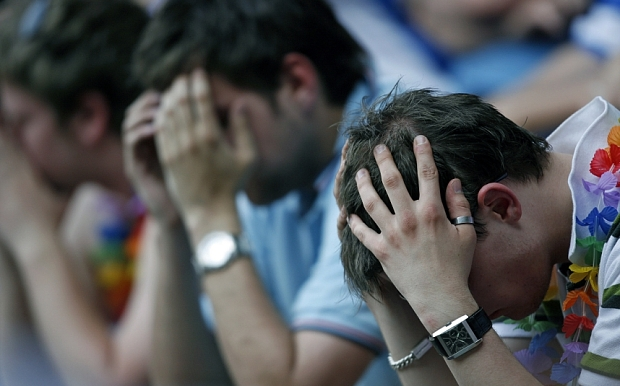